# R Notebook

#### Xuan Guo

CS5200

## Assignment 5

This is the assignment 5 of class CS5200 (Database Management System) which allow students to practice querying databases and dataframes in R with SQL.

```r
library(RSQLite)
library(sqldf)
# if database file already exists, we connect to it, otherwise
# we create a new database
dbcon <- dbConnect(RSQLite::SQLite(), "/Users/jacquelineguo/Documents/NEU/sqlite/MediaDB.db")
```

Q1. (20 pts) In the R Notebook, connect to the SQLite MediaDB.db Download MediaDB.dbdatabase and then load, using SQL SELECT, the “invoice_items” table into a data frame called rs. Add a new column to rs for the extended price called ExtPrice that is Quantity times Price. Using R, what is the average extended price (rounded to 2 decimals)? Do not use {sql} chunks for this entire question. You must use all R code; to do the query use one of dbExecute(), dbGetQuery(), or dbSendQuery().

```r
sqlCmd <- "SELECT * FROM invoice_items"
rs <- dbGetQuery(dbcon,sqlCmd)
rs$ExtPrice <- rs$UnitPrice*rs$Quantity
aveExtPrice <- format(round(mean(rs$ExtPrice),2))
rs
```

| InvoiceLineId | InvoiceId | TrackId | UnitPrice | Quantity | ExtPrice |
| --- | --- | --- | --- | --- | --- |
| 1 | 1 | 2 | 0.99 | 1 | 0.99 |
| 2 | 1 | 4 | 0.99 | 1 | 0.99 |
| 3 | 2 | 6 | 0.99 | 1 | 0.99 |
| 4 | 2 | 8 | 0.99 | 1 | 0.99 |
| 5 | 2 | 10 | 0.99 | 1 | 0.99 |
| 6 | 2 | 12 | 0.99 | 1 | 0.99 |
| 7 | 3 | 16 | 0.99 | 1 | 0.99 |
| 8 | 3 | 20 | 0.99 | 1 | 0.99 |
| 9 | 3 | 24 | 0.99 | 1 | 0.99 |
| 10 | 3 | 28 | 0.99 | 1 | 0.99 |

[output cut: 2230 more lines]

```r
aveExtPrice
```

```
## [1] "1.04"
```

Q2. (30 pts) Using sqldf, write a SQL query against the data frame rs from the question above that finds the total amount for each invoice (i.e., the sum of the extended prices for the invoice_items in each invoice) and the number of items in the invoice. So, the result set contains rows that each have the invoice ID, the total, and the number of items.

```r
rs1 <- sqldf("select InvoiceId, sum(ExtPrice) as Total, count(Quantity) as NumOfItems from rs group by InvoiceId")
rs1
```

| InvoiceId | Total | NumOfItems |
| --- | --- | --- |
| 1 | 1.98 | 2 |
| 2 | 3.96 | 4 |
| 3 | 5.94 | 6 |
| 4 | 8.91 | 9 |
| 5 | 13.86 | 14 |
| 6 | 0.99 | 1 |
| 7 | 1.98 | 2 |
| 8 | 1.98 | 2 |
| 9 | 3.96 | 4 |
| 10 | 5.94 | 6 |

[output cut: 402 more lines]

Q3. (30 pts) Using R and the result from the prior question, create a scatter plot of the total number of items in an invoice (x axis) versus the total (y axis). Add proper axis labels.

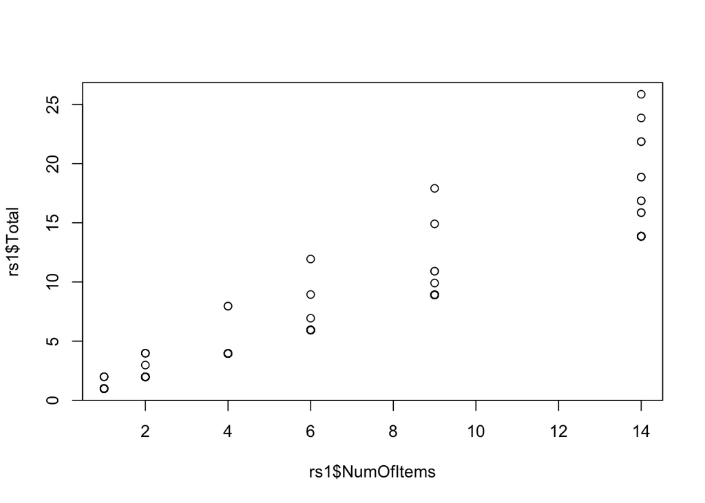

```r
plot(x = rs1$NumOfItems, y = rs1$Total)
```

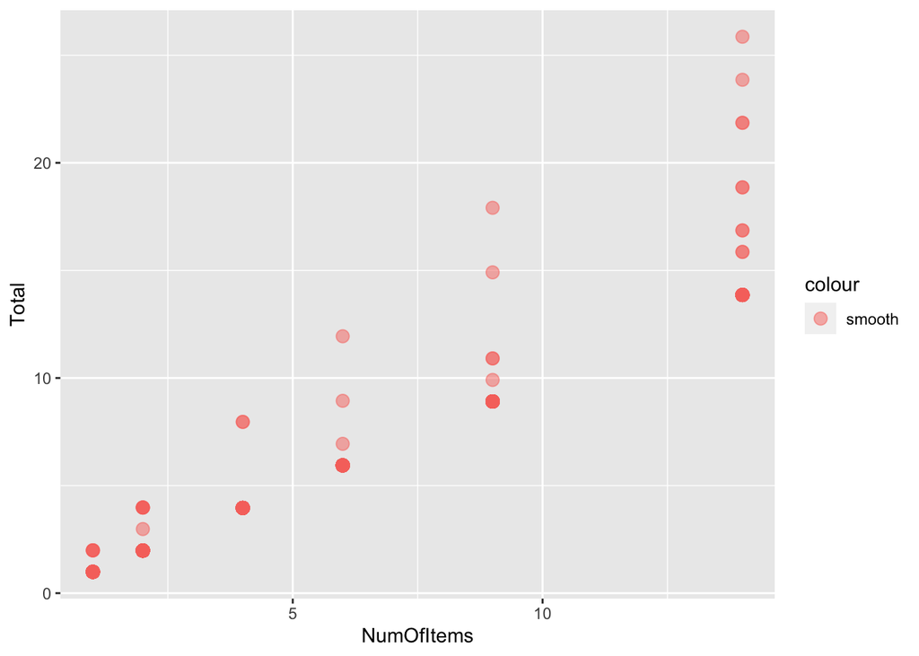

```r
 library(ggplot2)
ggplot(data=rs1, aes(x=NumOfItems, y=Total, color="smooth")) + geom_point(alpha=0.5, size=3)
```

Q4. (15 pts) Write and execute some combination of R code, loops in R, sqldf, dbWriteTable(), direct SQL ALTER and SQL UPDATE statements that applies a 10% discount to the total amount for each invoice if it has more than 5 items and stores that discounted amount in a new column in the invoices table called DiscPrice. This cannot be solved fully in sqldf nor fully with just a single UPDATE. You will need to use a combination of techniques and some creativity. Any approach will be acceptable.

```r
sqlAlterAdd <- "ALTER TABLE invoices ADD DiscPrice Numeric;"
dbGetQuery(dbcon, sqlAlterAdd)
```

```r
updateCmd <- "
  UPDATE invoices
  SET DiscPrice = ROUND(Total * 0.9, 2)
  WHERE InvoiceId IN
    (SELECT InvoiceId FROM invoice_items GROUP BY InvoiceId HAVING COUNT(Quantity) > 5);
  "
dbGetQuery(dbcon, updateCmd)
```

```r
updateCmd1 <- "
  UPDATE invoices
  SET DiscPrice = Total
  WHERE DiscPrice IS NULL;
  "
dbGetQuery(dbcon, updateCmd1)
```

Q5. (5 pts) Using a separate {r} chunk show that the update in (4) executed properly by displaying a part of the table.

```r
testQuery <- "SELECT * FROM invoices limit 30;"
test.df <- dbGetQuery(dbcon, testQuery)
head(test.df)
```

|  | InvoiceId | CustomerId | InvoiceDate | BillingAddress | BillingCity | BillingState | BillingCountry | BillingPostalCode | Total | DiscPrice |
| --- | --- | --- | --- | --- | --- | --- | --- | --- | --- | --- |
| 1 | 1 | 2 | 2009-01-01 00:00:00 | Theodor-Heuss-Straße 34 | Stuttgart | NA | Germany | 70174 | 1.98 | 1.98 |
| 2 | 2 | 4 | 2009-01-02 00:00:00 | Ullevålsveien 14 | Oslo | NA | Norway | 0171 | 3.96 | 3.96 |
| 3 | 3 | 8 | 2009-01-03 00:00:00 | Grétrystraat 63 | Brussels | NA | Belgium | 1000 | 5.94 | 5.35 |
| 4 | 4 | 14 | 2009-01-06 00:00:00 | 8210 111 ST NW | Edmonton | AB | Canada | T6G 2C7 | 8.91 | 8.02 |
| 5 | 5 | 23 | 2009-01-11 00:00:00 | 69 Salem Street | Boston | MA | USA | 2113 | 13.86 | 12.47 |
| 6 | 6 | 37 | 2009-01-19 00:00:00 | Berger Straße 10 | Frankfurt | NA | Germany | 60316 | 0.99 | 0.99 |

```r
sqlAlterDrop <- "ALTER TABLE invoices DROP COLUMN DiscPrice;"
dbGetQuery(dbcon, sqlAlterDrop)
```

```r
dbDisconnect(dbcon)
```